# ECE 5470 Lab 7 Report

## Part B, Section 3

```python
#Importing required libraries


import numpy as np
import pandas as pd
import sklearn
import matplotlib as mpl
import matplotlib.pyplot as plt
from sklearn.preprocessing import StandardScaler
from sklearn.neighbors import KNeighborsClassifier
from sklearn.decomposition import PCA
from sklearn.neural_network import MLPClassifier
from sklearn.svm import SVC
from sklearn.linear_model import SGDClassifier
from sklearn.metrics import precision_recall_fscore_support
from sklearn.metrics import accuracy_score
import time
from sklearn.metrics import confusion_matrix
```

### 3.1 K-NN model

You can visit this link for more information about K-NN classifier by sk.learn: https://scikit-learn.org/stable/modules/generated/sklearn.neighbors.KNeighborsClassifier.html

This part is executed by training a KNN model on the MNIST training data set. The following iterations are done in this training:

1. The full training data set of 60000 data samples is trained on KNN with k=1,3,5 neighbours
2. Then the training data set is shrinked to 20000 samples and is trained with k=1,3,5
3. Then PCA is used to transform the data to less number of dimensions keeping only the ones with higher variance and trained on the partial dataset

The function below allows you to conveniently train and test a KNN classifier with a single command.

```python
#Partial Data
X_train1, X_test1 = X[:20000], X[20000:]
y_train1, y_test1 = y[:20000], y[20000:]
```

```python
# KNN FUNCTION

def KNN(train_features, train_labels, test_features, test_labels, k):
    knn = KNeighborsClassifier(n_neighbors=k)
    start_time = time.time()
    knn.fit(train_features,train_labels)
    train_time = time.time() - start_time

    start_time = time.time()
    print('value of k' , k)
    print('training time' , train_time)
    score_test = knn.score(test_features,test_labels)
    score_training =knn.score(train_features,train_labels)
    test_pred = knn.predict(test_features)

    test_time = time.time() - start_time

    print('Score test' , score_test)
    print('train_score' , score_training)

    print('test time' ,test_time)
    cfm = confusion_matrix(test_labels, test_pred)
    print (cfm)
```

```python
print('KNN with full data for k = 1')
KNN(X_train , y_train , X_test , y_test , 1)

print('KNN with full data for k = 3')
KNN(X_train , y_train , X_test , y_test , 3)

print('KNN with full data for k = 5')
KNN(X_train , y_train , X_test , y_test , 5)
```

```
KNN with full data for k = 1
value of k 1
training time 0.05213522911071777
Score test 0.9434
train_score 1.0
test time 297.67092394828796
[[ 965    1    0    3    1    4    5    0    1    0]
 [   0 1127    3    1    1    0    3    0    0    0]
 [  10    7  966   19    4    0    3   10    9    4]
 [   0    2    3  949    2   19    1   11   16    7]
 [   1    9    5    1  920    2    5    6    3   30]
 [   5    0    1   30    4  813   12    1   18    8]
 [  13    4    1    2    4    5  929    0    0    0]
 [   0   14   11    4    6    1    0  959    1   32]
 [  14    2    7   20    8   30    3    8  875    7]
 [   4    4    6    9   15    6    0   30    4  931]]
KNN with full data for k = 3
value of k 3
training time 0.054379940032958984
Score test 0.9452
train_score 0.9727666666666667
test time 289.16002202033997
[[ 967    0    1    3    0    4    5    0    0    0]
 [   0 1127    3    0    1    0    3    0    1    0]
 [  12    9  967   15    2    0    5   11    9    2]
 [   0    4    5  963    2   14    0   12    8    2]
 [   1    9    5    2  922    2    7    4    3   27]
 [   7    0    6   21    4  828    9    2    7    8]
 [  13    4    2    0    3    9  925    0    2    0]
 [   0   22   12    4    7    2    0  953    1   27]
 [  15    3    9   24   10   22    3    7  874    7]
 [   5    6    6   11   17    7    0   28    3  926]]
KNN with full data for k = 5
value of k 5
training time 0.04567766189575195
Score test 0.9443
train_score 0.96425
test time 283.35251784324646
[[ 963    0    1    3    1    5    6    1    0    0]
 [   0 1129    3    0    0    0    3    0    0    0]
 [  14    6  960   20    5    0    7    9   10    1]
 [   0    3    5  962    3   13    0   10   10    4]
 [   1   10    5    3  922    3    6    4    2   26]
 [   5    1    3   23    8  824   13    2    6    7]
 [  10    4    2    1    3    6  929    0    3    0]
 [   0   21   12    4    8    2    0  949    1   31]
 [  13    3    6   18    8   30    3    6  880    7]
 [   6    5    5   10   18    6    0   31    3  925]]
```

#### Partial Data KNN

```python
print('KNN with partial data for k = 1')
KNN(X_train1 , y_train1 , X_test1 , y_test1 , 1)

print('KNN with partial data for k = 3')
KNN(X_train1 , y_train1 , X_test1 , y_test1 , 3)

print('KNN with partial data for k = 5')
KNN(X_train1 , y_train1 , X_test1 , y_test1 , 5)
```

```
KNN with partial data for k = 1
value of k 1
training time 0.12392163276672363
Score test 0.95696
train_score 1.0
test time 168.86676335334778
[[4845    5   11    4    2    6   21    4    7    4]
 [   1 5551   16   11    2    3    3    5    2    2]
 [  51   34 4798   27    9    8   19   93   18    4]
 [   6   11   34 4810    2  100    3   27   49   23]
 [   5   37    1    1 4620    1   16   20    3  175]
 [  18   11    2   93   11 4278   60    8   28   29]
 [  33   10    2    2    8   25 4820    0    4    1]
 [   3   71   21    2   20    1    0 4998    1   83]
 [  23   46   21  109   19  130   30   25 4436   64]
 [  14   15    7   25   79   13    1   83   15 4692]]
KNN with partial data for k = 3
value of k 3
training time 0.016594409942626953
Score test 0.95742
train_score 0.98065
test time 155.55546307563782
[[4869    5    6    2    0    4   17    2    3    1]
 [   1 5560   10    8    1    1    4    8    1    2]
 [  61   54 4770   25    6    3   17  106   15    4]
 [  10   17   38 4839    2   69    4   32   33   21]
 [   8   48    2    2 4622    1   18   11    3  164]
 [  26   16    5  102    9 4284   49    6   19   22]
 [  24   12    2    2    7   26 4831    0    1    0]
 [   5   86   21    2   20    2    0 4986    0   78]
 [  38   67   38  110   30  113   16   24 4404   63]
 [  21   20   13   41   63   12    1   59    8 4706]]
KNN with partial data for k = 5
value of k 5
training time 0.017898082733154297
Score test 0.95652
train_score 0.9738
test time 163.87539148330688
[[4858    6    5    3    0    9   22    3    1    2]
 [   1 5561   11    7    0    1    4    8    1    2]
 [  61   64 4757   21    7    3   17  107   17    7]
 [   6   19   31 4848    2   63    5   34   34   23]
 [   6   50    2    1 4622    0   21   10    3  164]
 [  23   19    4   88    8 4293   56    5   14   28]
 [  24   16    2    2    6   24 4829    0    1    1]
 [   2   94   20    4   20    0    0 4982    0   78]
 [  30   79   28  102   29  137   25   31 4373   69]
 [  21   21   11   38   56   13    2   72    7 4703]]
```

#### PCA with KNN

```python
def KNN_PCA(train_features, train_labels, test_features, test_labels, k, n_comp):

    pca = PCA(n_components=n_comp)
    pca.fit(X_train)
    train_features_pca = pca.transform(train_features)
    test_features_pca = pca.transform(test_features)


    knn = KNeighborsClassifier(n_neighbors=k)
    start_time = time.time()
    knn.fit(train_features_pca,train_labels)
    train_time = time.time() - start_time

    start_time = time.time()
    print(k)
    print(train_time)
    score_test = knn.score(test_features_pca,test_labels)
    score_train =knn.score(train_features_pca,train_labels)
    test_pred = knn.predict(test_features_pca)

    test_time = time.time() - start_time

    print(score_test)
    print(score_train)

    print(test_time)
    cfm = confusion_matrix(test_labels, test_pred)
    print (cfm)
```

```python
print('KNN_PCA with partial data for k = 1')
KNN_PCA(X_train1 , y_train1 , X_test1 , y_test1 , 1 , 20)

print('KNN_PCA with partial data for k = 3')
KNN_PCA(X_train1 , y_train1 , X_test1 , y_test1 , 3 , 20)

print('KNN_PCA with partial data for k = 5')
KNN_PCA(X_train1 , y_train1 , X_test1 , y_test1 , 5 , 20)
```

```
KNN_PCA with partial data for k = 1
1
0.0074176788330078125
0.93912
1.0
19.064401626586914
[[4809    4   17    6    0   16   36    2   14    5]
 [   0 5523   26   12    2    3    4    7   15    4]
 [  35   11 4825   46   11    4   18   55   47    9]
 [   3   14   56 4592    7   97    3   38  216   39]
 [   5   11   14    2 4484    8   32   15   14  294]
 [  22    7    9   98    8 4195   70    5   83   41]
 [  26    7    4    2   12   44 4791    0   17    2]
 [   2   42   41   21   26    4    0 4849   12  203]
 [  20   28   37  138   16  102   31   16 4430   85]
 [  13   20   11   42  203   27    1  124   45 4458]]
KNN_PCA with partial data for k = 3
3
0.0069234371185302734
0.94574
0.9761
19.732738733291626
[[4831    3   13    4    4   12   26    1   14    1]
 [   1 5535   25   11    4    1    4    4    7    4]
 [  39    8 4857   29    9    4   17   43   52    3]
 [   9   25   49 4612    4   90    2   35  206   33]
 [  11   18   14    1 4519    7   33    9    4  263]
 [  36   11    7   92   11 4234   52    4   59   32]
 [  25    7    5    3   10   36 4809    0   10    0]
 [   3   52   36   10   44    4    1 4873    5  172]
 [  37   34   39  107   22   93   16   14 4488   53]
 [  24   25   10   58  164   29    2   83   20 4529]]
KNN_PCA with partial data for k = 5
5
0.007340669631958008
0.94644
0.96805
19.228504419326782
[[4823    5   15    3    1   15   29    2   15    1]
 [   0 5534   21   13    3    2    7    5    7    4]
 [  35   10 4857   20    8    6   22   47   51    5]
 [  10   25   45 4605    9   89    3   34  211   34]
 [   9   16   15    1 4512    8   39    7    4  268]
 [  24    6    7   94    9 4253   58    4   43   40]
 [  18    8    2    0   12   37 4819    0    9    0]
 [   4   54   33   10   41    3    0 4891    7  157]
 [  27   38   37   99   16  103   21   11 4486   65]
 [  19   26   10   52  136   29    1   99   30 4542]]
```

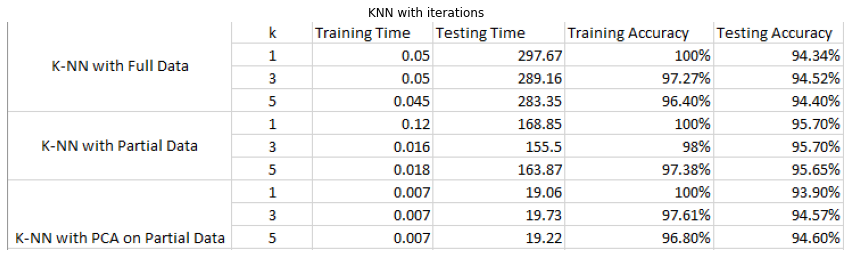

```python
image = plt.imread("knn.PNG")
plt.figure(figsize=(15, 9))
plt.imshow(image)
plt.title("KNN with iterations")
plt.axis("off")
plt.show()
```

Discussion:

We see that as we increase the value of k, the training accuracy reduces. In all iterations with partial data and with PCA, the training accuracy reduces as we increase the k nearet neighbours. We also see that when model is trained on partial data, the testing accuracy increases. This highlights that there is a chance that the model was overfit on the training data and hence was less generalized for other test datasets. This means lesser dataset was better for the generalization of the model.

We also notice that when we apply PCA to the training data, our testing time drastically reduces. This happens because when we apply PCA, the dimensions of the data are reduced only to the dimensions or features which has the highest variance. Therefore, due to less dimensions in place, our accuracy is not compromised but the testing time of the data decreseases drastically which saves computational cost. Similarly the training time is also very low in PCA since less dimensions are used for the training. THe training accuracy in PCA is a little lower and the reason of this may be the missing out dimensions with low variance but the trade off is justified since the difference in accuracy is minute whereas the time taken to test is substantially lower.

#### B. Part 2 - Multi Layer Perceptron

```python
# mlp = MLPClassifier(hidden_layer_sizes=(100, 100), max_iter=400, alpha=1e-4,


def MLP_singlelayer(train_features, train_labels, test_features, test_labels, hid_layer_size):

    mlp = MLPClassifier(hidden_layer_sizes=(hid_layer_size,), max_iter=20, alpha=1e-4,
                    solver='sgd', verbose=10,
                    learning_rate_init=.1)

    start_time = time.time()
    mlp.fit(train_features,train_labels)
    train_time = time.time() - start_time

    start_time = time.time()
    #print(k)
    print('Train time: ' ,train_time)
    score_test = mlp.score(test_features,test_labels)
    score_train = mlp.score(train_features,train_labels)
    test_pred = mlp.predict(test_features)

    test_time = time.time() - start_time

    print('Test Score' , score_test)
    print('training score ' ,score_train)

    print('test time' , test_time)
    cfm = confusion_matrix(test_labels, test_pred)
    print (cfm)
```

#### Single hidden layer MLP on full data and partial data

```python
print('MLP with one hidden layer on full training data')
MLP_singlelayer(X_train, y_train, X_test, y_test, 50)
print('MLP with one hidden layer on full training data')
MLP_singlelayer(X_train1, y_train1, X_test1, y_test1, 50)
```

```
MLP with one hidden layer on full training data
Iteration 1, loss = 0.30553592
Iteration 2, loss = 0.22167471
Iteration 3, loss = 0.23627193
Iteration 4, loss = 0.22569824
Iteration 5, loss = 0.22035187
Iteration 6, loss = 0.24412051
Iteration 7, loss = 0.27025535
Iteration 8, loss = 0.22221857
Iteration 9, loss = 0.17465046
Iteration 10, loss = 0.15080517
Iteration 11, loss = 0.15665666
Iteration 12, loss = 0.15921464
Iteration 13, loss = 0.19102081
Iteration 14, loss = 0.21841866
Iteration 15, loss = 0.24435051
Iteration 16, loss = 0.22630026
Iteration 17, loss = 0.21444883
Iteration 18, loss = 0.21882541
Iteration 19, loss = 0.21312148
Iteration 20, loss = 0.20285563
Train time:  25.078760623931885
```

```
Test Score 0.9611
training score  0.9820333333333333
test time 0.5000851154327393
[[ 966    0    2    1    1    3    3    1    3    0]
 [   0 1117    5    0    8    2    0    2    1    0]
 [   4    0  998    6    2    1    6    8    7    0]
 [   0    0    7  972    0   19    0    5    4    3]
 [   4    0    9    2  938    0    4    5    4   16]
 [   2    2    2    7    1  860    3    3    6    6]
 [   7    5    4    1    6   10  922    0    3    0]
 [   1    3   15    5   14    0    0  974    1   15]
 [   1    2    6    9    7   29    3    9  906    2]
 [   4    2    0   13   17    2    1    9    3  958]]
MLP with one hidden layer on full training data
Iteration 1, loss = 0.52940580
Iteration 2, loss = 0.25197918
Iteration 3, loss = 0.18653593
Iteration 4, loss = 0.14637298
Iteration 5, loss = 0.11810865
Iteration 6, loss = 0.10124688
Iteration 7, loss = 0.08527019
Iteration 8, loss = 0.07235402
Iteration 9, loss = 0.06009725
Iteration 10, loss = 0.05413540
Iteration 11, loss = 0.04660867
Iteration 12, loss = 0.04218342
Iteration 13, loss = 0.03727251
Iteration 14, loss = 0.03034149
Iteration 15, loss = 0.02681483
Iteration 16, loss = 0.02365439
Iteration 17, loss = 0.02025256
Iteration 18, loss = 0.01823139
Iteration 19, loss = 0.01511150
Iteration 20, loss = 0.01474395
Train time:  8.656497955322266
```

```
Test Score 0.95872
training score  0.99865
test time 0.7593691349029541
[[4791    1   17   11    3   17   35    5   18   11]
 [   1 5520   17   20    3    2    5    9   14    5]
 [  28   18 4837   66   18    2   21   37   22   12]
 [   8   12   40 4868    1   42    2   24   48   20]
 [  10   10   13    4 4619    5   41   14   18  145]
 [  23   10   13  102   10 4252   45   20   39   24]
 [  16   12   14    2   24   25 4795    4   13    0]
 [  12   29   55   57   17    5    1 4959    8   57]
 [  23   34   31   77    9   55   27   11 4602   34]
 [  24   10    4   63   47   22    0   56   25 4693]]
```

#### two hidden layer MLP on full data and partial data

```python
# mlp = MLPClassifier(hidden_layer_sizes=(100, 100), max_iter=400, alpha=1e-4,


def MLP_twolayer(train_features, train_labels, test_features, test_labels, hid_layer_size):

    mlp = MLPClassifier(hidden_layer_sizes=(hid_layer_size,hid_layer_size), max_iter=20, alpha=1e-4,
                    solver='sgd', verbose=10,
                    learning_rate_init=.1)

    start_time = time.time()
    mlp.fit(train_features,train_labels)
    train_time = time.time() - start_time

    start_time = time.time()
    #print(k)
    print('training time ',train_time)
    score_test = mlp.score(test_features,test_labels)
    score_train = mlp.score(train_features,train_labels)
    test_pred = mlp.predict(test_features)

    test_time = time.time() - start_time

    print('test score ',score_test)
    print('training score ',score_train)

    print('test time',test_time)
    cfm = confusion_matrix(test_labels, test_pred)
    print (cfm)
```

```python
print('MLP with two hidden layer on full training data')
MLP_twolayer(X_train, y_train, X_test, y_test, 50)
print('MLP with tw0 hidden layer on full training data')
MLP_twolayer(X_train1, y_train1, X_test1, y_test1, 50)
```

```
MLP with two hidden layer on full training data
Iteration 1, loss = 0.28973797
Iteration 2, loss = 0.17041593
Iteration 3, loss = 0.17260302
Iteration 4, loss = 0.13740505
Iteration 5, loss = 0.12465157
Iteration 6, loss = 0.11393621
Iteration 7, loss = 0.09133003
Iteration 8, loss = 0.08382770
Iteration 9, loss = 0.07679033
Iteration 10, loss = 0.07083727
Iteration 11, loss = 0.07265758
Iteration 12, loss = 0.07694570
Iteration 13, loss = 0.09744754
Iteration 14, loss = 0.08510849
Iteration 15, loss = 0.08681993
Iteration 16, loss = 0.07734623
Iteration 17, loss = 0.07140290
Iteration 18, loss = 0.07368897
Iteration 19, loss = 0.06420060
Iteration 20, loss = 0.05504982
training time  27.855942010879517
```

```
test score  0.962
training score  0.9844333333333334
test time 0.5635740756988525
[[ 963    0    2    5    0    1    6    1    2    0]
 [   0 1126    2    1    0    1    3    1    1    0]
 [   4    2  992   15    2    0    6    6    4    1]
 [   0    0    7  976    0   13    0    4    4    6]
 [   0    0    4    7  934    0    6    2    1   28]
 [   3    1    0   18    1  841   12    2    7    7]
 [   4    3    2    4    3    3  936    2    1    0]
 [   0    4   11    9    1    1    1  995    1    5]
 [   1    0    6   34    5    8    3    5  910    2]
 [   4    2    0   18    9    4    1   17    7  947]]
MLP with tw0 hidden layer on full training data
Iteration 1, loss = 0.55867242
Iteration 2, loss = 0.19123152
Iteration 3, loss = 0.13695456
Iteration 4, loss = 0.10632690
Iteration 5, loss = 0.08857691
Iteration 6, loss = 0.07002306
Iteration 7, loss = 0.05770997
Iteration 8, loss = 0.04622428
Iteration 9, loss = 0.03778265
Iteration 10, loss = 0.03130629
Iteration 11, loss = 0.03028085
Iteration 12, loss = 0.02221359
Iteration 13, loss = 0.01794078
Iteration 14, loss = 0.01688992
Iteration 15, loss = 0.01596160
Iteration 16, loss = 0.01485542
Iteration 17, loss = 0.01274805
Iteration 18, loss = 0.00668220
Iteration 19, loss = 0.00778941
Iteration 20, loss = 0.00932114
training time  11.17584776878357
```

```
test score  0.95822
training score  0.9975
test time 0.8006103038787842
[[4791    4   24   11   15   11   23    3   18    9]
 [   1 5518   28   11   11    1    5    7    9    5]
 [  27   16 4877   44   28    6   15   20   20    8]
 [  12    9   49 4858   10   40    3   11   39   34]
 [   7    8   13    4 4747    0   11    5    4   80]
 [  19   14   11  115   19 4188   54   13   57   48]
 [  23   10   20    7   67   20 4733    0   25    0]
 [  16   36   68   45   37    2    0 4898   11   87]
 [  22   46   30   86   31   35   18    5 4572   58]
 [  11    9    1   37  103   10    0   30   14 4729]]
```

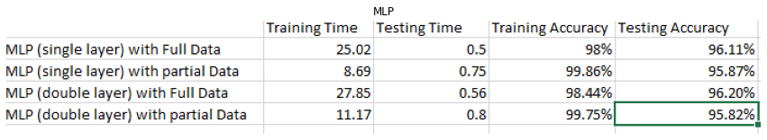

```python
image = plt.imread("mlp.PNG")
plt.figure(figsize=(15, 9))
plt.imshow(image)
plt.title("MLP")
plt.axis("off")
plt.show()
```

Discussion: